# The Politics of X

A methodology for finding words that are worth 60 seconds

Author

Claude Code

Published

September 20, 2026

```r
library(tidyverse)
library(ggrepel)
library(patchwork)
library(gt)

theme_set(theme_minimal(base_size = 12))
set.seed(1312)
```

## The problem, stated so it can be measured

“Politicize This” deals a word; a player has 30–60 seconds to argue it is political. The deck currently holds a mix of words that do very different work in play, and the two failure modes are not symmetrical:

- **The lecture.** *Debt*, *Hunger*, *AI*. Everyone already knows these are political. The player recites the seminar answer, nobody is surprised, the table waits.
- **The blank.** A word so far from politics that no angle arrives at all. Dead air, then a rescue from someone else.

What we want sits between them: the word that looks apolitical for about one second and then opens up. The design brief for this round is explicit — **less serious is more fun, and it shouldn’t be obvious.** That is not a mood; it is a constraint on which cells of the design space we are willing to fill.

So the construct is:

> **Interesting = the distance the player has to travel × the number of roads they can travel on.**

Distance without roads is the blank. Roads without distance is the lecture.

## The instrument

Four codes per word. Three are judgments on a 1–5 scale; the fourth is a checklist, which is the part that makes “it has depth” countable instead of a vibe.

```r
tribble(
  ~code, ~type, ~definition,
  "distance", "1–5", "How apolitical it looks at first glance. 1 = the word is already a political topic (Debt). 5 = a table would laugh at the idea it is political (Sock Length).",
  "register", "serious / chaos", "Tone of the word itself, independent of distance. The brief wants chaos.",
  "concreteness", "1–5", "Does everyone at the table picture the same thing instantly? 1 = abstract (Becoming). 5 = a shared physical image (Hotel Breakfast).",
  "frames", "checklist", "Which political frames the word plausibly opens. Traction is the count."
) |>
  gt() |>
  tab_header(title = "Codes") |>
  cols_label(code = "Code", type = "Scale", definition = "What it asks") |>
  tab_options(table.font.size = 12)
```

Codes

| Code | Scale | What it asks |
| --- | --- | --- |
| distance | 1–5 | How apolitical it looks at first glance. 1 = the word is already a political topic (Debt). 5 = a table would laugh at the idea it is political (Sock Length). |
| register | serious / chaos | Tone of the word itself, independent of distance. The brief wants chaos. |
| concreteness | 1–5 | Does everyone at the table picture the same thing instantly? 1 = abstract (Becoming). 5 = a shared physical image (Hotel Breakfast). |
| frames | checklist | Which political frames the word plausibly opens. Traction is the count. |

### The frame inventory

The frame list is the load-bearing part. A word earns a frame if a reasonably informed player could get to that argument inside a minute without stretching.

```r
frame_defs <- tribble(
  ~frame, ~opens,
  "labor",  "Who does the work, who is paid for it, who is on call",
  "class",  "Money, access, status, who can afford the nice version",
  "gender", "Who is expected to do it, whose comfort is default",
  "race",   "Race, migration, colonial history, whose version is 'authentic'",
  "state",  "Law, regulation, policing, taxation, licensing",
  "infra",  "Infrastructure, platforms, standards, defaults someone chose",
  "env",    "Resources, waste, climate, what it costs the planet",
  "care",   "Dependency, health, disability, who is looked after",
  "norms",  "Etiquette, taste, respectability, shame",
  "body",   "Bodies, ability, discipline, disgust",
  "time",   "Whose time is assumed to be free",
  "space",  "Public space, property, who is allowed to be where"
)

frame_defs |>
  gt() |>
  tab_header(title = "Twelve frames") |>
  cols_label(frame = "Frame", opens = "The argument it opens") |>
  tab_options(table.font.size = 12)
```

Twelve frames

| Frame | The argument it opens |
| --- | --- |
| labor | Who does the work, who is paid for it, who is on call |
| class | Money, access, status, who can afford the nice version |
| gender | Who is expected to do it, whose comfort is default |
| race | Race, migration, colonial history, whose version is 'authentic' |
| state | Law, regulation, policing, taxation, licensing |
| infra | Infrastructure, platforms, standards, defaults someone chose |
| env | Resources, waste, climate, what it costs the planet |
| care | Dependency, health, disability, who is looked after |
| norms | Etiquette, taste, respectability, shame |
| body | Bodies, ability, discipline, disgust |
| time | Whose time is assumed to be free |
| space | Public space, property, who is allowed to be where |

**WarningThese codings are one coder’s first pass**

Every code in `data/word-codes.csv` is my judgment, written in one sitting, to give the method something real to chew on. They are a starting argument, not data. Before any of this is load-bearing, a second coder should code the same words blind and the agreement should be checked (see Reliability). Where we disagree is usually where the interesting design question is hiding.

## Loading the deck

```r
words <- jsonlite::fromJSON("../data/words.json")

codes <- read_csv("../notebooks/data/word-codes.csv", show_col_types = FALSE) |>
  mutate(
    frame_set = str_split(frames, ";"),
    traction = lengths(frame_set)
  )

coverage <- list(
  uncoded = setdiff(words, codes$word),
  stray   = setdiff(codes$word, words)
)

cat(
  "deck: ", length(words), " words | coded: ", nrow(codes),
  "\nuncoded (in deck, missing a code row): ",
  if (length(coverage$uncoded)) paste(coverage$uncoded, collapse = ", ") else "none",
  "\nstray (coded, no longer in deck): ",
  if (length(coverage$stray)) paste(coverage$stray, collapse = ", ") else "none",
  "\n", sep = ""
)
```

```
deck: 68 words | coded: 69
uncoded (in deck, missing a code row): Bottled Water, Fortune Cookies, Body Odor
stray (coded, no longer in deck): Debt, Language, Hunger, Water
```

The word bank is edited by hand and often, so this check runs first and loudly: new words show up as uncoded, deleted ones as stray. Neither is an error — it is a to-do list.

## Audit: where the deck actually sits

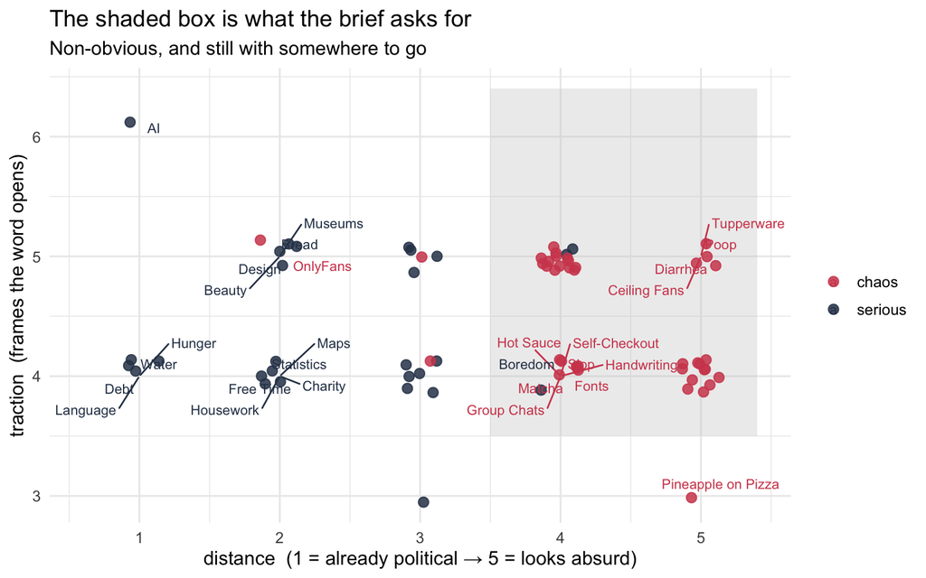

Each word placed by how far it has to travel and how many roads it has. Labels are thinned to the extremes.

```r
plot_dat <- codes |>
  mutate(
    quadrant = case_when(
      distance >= 4 & traction >= 4 ~ "the good cell",
      distance <= 2 & traction >= 4 ~ "lecture",
      distance >= 4 & traction <= 3 ~ "thin",
      TRUE ~ "middle"
    )
  )

ggplot(plot_dat, aes(distance, traction, colour = register)) +
  annotate("rect", xmin = 3.5, xmax = 5.4, ymin = 3.5, ymax = 6.4,
           fill = "grey80", alpha = 0.35) +
  geom_jitter(width = 0.14, height = 0.14, size = 2.6, alpha = 0.85) +
  geom_text_repel(
    data = filter(plot_dat, quadrant != "middle"),
    aes(label = word), size = 3, max.overlaps = 18, seed = 1
  ) +
  scale_colour_manual(values = c(chaos = "#d1495b", serious = "#2e4057")) +
  scale_x_continuous(breaks = 1:5, limits = c(0.6, 5.4)) +
  scale_y_continuous(breaks = 1:6) +
  labs(
    x = "distance  (1 = already political → 5 = looks absurd)",
    y = "traction  (frames the word opens)",
    colour = NULL,
    title = "The shaded box is what the brief asks for",
    subtitle = "Non-obvious, and still with somewhere to go"
  )
```

```r
plot_dat |>
  count(quadrant, register) |>
  pivot_wider(names_from = register, values_from = n, values_fill = 0) |>
  mutate(total = chaos + serious) |>
  arrange(desc(total)) |>
  gt() |>
  tab_header(title = "How the current deck splits") |>
  tab_options(table.font.size = 12)
```

How the current deck splits

| quadrant | chaos | serious | total |
| --- | --- | --- | --- |
| the good cell | 37 | 3 | 40 |
| lecture | 1 | 14 | 15 |
| middle | 2 | 11 | 13 |
| thin | 1 | 0 | 1 |

Two findings worth acting on:

```r
n_lecture <- sum(codes$distance <= 2)
n_abstract <- sum(codes$concreteness <= 2)
share_class <- mean(map_lgl(codes$frame_set, ~ "class" %in% .x))

cat(
  "words at distance <= 2 (the lecture zone): ", n_lecture,
  " of ", nrow(codes), "\n",
  "words at concreteness <= 2 (nothing to picture): ", n_abstract, "\n",
  "share of words that open the 'class' frame: ", round(100 * share_class), "%\n",
  sep = ""
)
```

```
words at distance <= 2 (the lecture zone): 15 of 69
words at concreteness <= 2 (nothing to picture): 4
share of words that open the 'class' frame: 90%
```

1. **The lecture zone is over-stocked.** Those words are not bad; they are just already on the syllabus. They are the cards a player performs rather than thinks through.
2. **`class` is nearly constant.** If ~9 in 10 words open a class argument, the frame does not discriminate between words. It stays in the instrument because it is true, but traction is more informative when computed *without* the frames that every word has.

```r
ubiquitous <- frame_defs$frame[
  map_dbl(frame_defs$frame, \(f) mean(map_lgl(codes$frame_set, ~ f %in% .x))) > 0.8
]

codes <- codes |>
  mutate(
    traction_distinct = map_int(frame_set, ~ length(setdiff(.x, ubiquitous)))
  )

cat("treated as ubiquitous and excluded from distinctive traction: ",
    paste(ubiquitous, collapse = ", "), "\n", sep = "")
```

```
treated as ubiquitous and excluded from distinctive traction: class
```

### Frame coverage

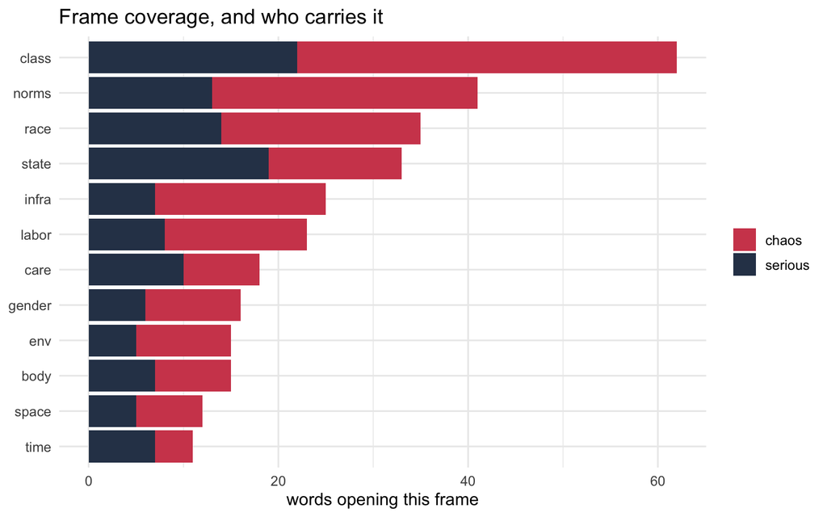

Which arguments the deck can currently produce, split by register.

```r
codes |>
  select(word, register, frame_set) |>
  unnest(frame_set) |>
  count(frame = frame_set, register) |>
  mutate(frame = fct_reorder(frame, n, sum)) |>
  ggplot(aes(n, frame, fill = register)) +
  geom_col() +
  scale_fill_manual(values = c(chaos = "#d1495b", serious = "#2e4057")) +
  labs(x = "words opening this frame", y = NULL, fill = NULL,
       title = "Frame coverage, and who carries it")
```

Read this column by register, not in total. A frame that only the *serious* words carry is a frame the deck cannot reach while staying funny — and staying funny is the brief. Those are the cells candidates should target.

### Redundancy: which cards are the same card

Two words with the same frame signature produce the same conversation. In a deck meant to be played end to end, that is worse than a weak word.

```r
frame_matrix <- codes |>
  select(word, frame_set) |>
  unnest(frame_set) |>
  mutate(present = 1) |>
  pivot_wider(names_from = frame_set, values_from = present, values_fill = 0) |>
  column_to_rownames("word") |>
  as.matrix()

jaccard <- proxy::simil(frame_matrix, method = "Jaccard")
pairs <- as.data.frame(as.table(as.matrix(jaccard))) |>
  rename(a = Var1, b = Var2, similarity = Freq) |>
  filter(as.character(a) < as.character(b), similarity >= 0.75) |>
  arrange(desc(similarity))

pairs |>
  head(15) |>
  mutate(similarity = round(similarity, 2)) |>
  gt() |>
  tab_header(
    title = "Near-identical cards",
    subtitle = "Jaccard similarity of frame signatures ≥ 0.75"
  ) |>
  tab_options(table.font.size = 12)
```

Near-identical cards

Jaccard similarity of frame signatures ≥ 0.75

| a | b | similarity |
| --- | --- | --- |
| Debt | Waiting | 1 |
| Water | Weather | 1 |
| Fonts | Handwriting | 1 |
| Museums | Noise | 1 |
| Catan | Lawns | 1 |
| Group Chats | Reply All | 1 |
| Cilantro | Hot Sauce | 1 |
| Cargo Shorts | The Aux Cord | 1 |
| Sock Length | The Aux Cord | 1 |
| Air Conditioning | Ceiling Fans | 1 |
| Cargo Shorts | Sock Length | 1 |
| Accents | Pineapple on Pizza | 1 |
| Group Chats | Slop | 1 |
| Reply All | Slop | 1 |
| Cheese | Fireworks | 1 |

This is a cut list, not a bug list: keep the funnier member of each pair.

## The screening rule

A candidate word has to clear floors before its score means anything. The floors encode the brief; the weights are placeholders until playtests exist.

```r
FLOORS <- list(distance = 4, concreteness = 4, traction = 3)

WEIGHTS <- c(distance = 1.0, traction_distinct = 0.6, concreteness = 0.4, chaos_bonus = 0.5)

score_words <- function(df) {
  df |>
    mutate(
      frame_set = if (is.list(frames)) frames else str_split(frames, ";"),
      traction = lengths(frame_set),
      traction_distinct = map_int(frame_set, ~ length(setdiff(.x, ubiquitous))),
      passes = distance >= FLOORS$distance &
        concreteness >= FLOORS$concreteness &
        traction >= FLOORS$traction,
      score = WEIGHTS[["distance"]] * distance +
        WEIGHTS[["traction_distinct"]] * traction_distinct +
        WEIGHTS[["concreteness"]] * concreteness +
        WEIGHTS[["chaos_bonus"]] * (register == "chaos")
    )
}
```

**NoteThe weights are guesses and are meant to be replaced**

`WEIGHTS` is a hunch about what makes a card land, written to match the brief (distance weighted hardest, chaos rewarded). The Playtest section replaces these numbers with estimates from actual sessions. Until then the score is a sorting convenience, not a measurement.

```r
scored_deck <- score_words(codes)

scored_deck |>
  arrange(desc(score)) |>
  transmute(word, register, distance, traction, concreteness,
            score = round(score, 1), passes) |>
  slice(c(1:8, (n() - 7):n())) |>
  gt() |>
  tab_header(title = "Current deck, best and worst by the rubric") |>
  tab_row_group(label = "weakest", rows = 9:16) |>
  tab_row_group(label = "strongest", rows = 1:8) |>
  tab_options(table.font.size = 12)
```

Current deck, best and worst by the rubric

| word | register | distance | traction | concreteness | score | passes |
| --- | --- | --- | --- | --- | --- | --- |
| strongest |  |  |  |  |  |  |
| Tupperware | chaos | 5 | 5 | 5 | 9.9 | TRUE |
| Diarrhea | chaos | 5 | 5 | 5 | 9.9 | TRUE |
| Ceiling Fans | chaos | 5 | 5 | 5 | 9.9 | TRUE |
| Dishwasher Loading | chaos | 5 | 4 | 5 | 9.9 | TRUE |
| Poop | chaos | 5 | 5 | 5 | 9.9 | TRUE |
| Loading Screens | chaos | 5 | 4 | 5 | 9.3 | TRUE |
| Office Birthdays | chaos | 5 | 4 | 5 | 9.3 | TRUE |
| Cargo Shorts | chaos | 5 | 4 | 5 | 9.3 | TRUE |
| weakest |  |  |  |  |  |  |
| Free Time | serious | 2 | 4 | 4 | 5.4 | FALSE |
| AI | serious | 1 | 6 | 3 | 5.2 | FALSE |
| Design | serious | 2 | 5 | 2 | 5.2 | FALSE |
| Statistics | serious | 2 | 4 | 3 | 5.0 | FALSE |
| Water | serious | 1 | 4 | 5 | 4.8 | FALSE |
| Debt | serious | 1 | 4 | 4 | 4.4 | FALSE |
| Hunger | serious | 1 | 4 | 4 | 4.4 | FALSE |
| Language | serious | 1 | 4 | 3 | 4.0 | FALSE |

## Generating candidates against the gaps

Candidates are written *after* the audit, aimed at the thin cells: frames the chaos register cannot currently reach, and domains where every word we have is serious.

```r
gap_targets <- codes |>
  select(word, register, frame_set) |>
  unnest(frame_set) |>
  count(frame = frame_set, register) |>
  pivot_wider(names_from = register, values_from = n, values_fill = 0) |>
  mutate(chaos_share = chaos / (chaos + serious)) |>
  arrange(chaos_share)

gap_targets |>
  gt() |>
  fmt_percent(chaos_share, decimals = 0) |>
  tab_header(title = "Frames the funny half of the deck can't reach") |>
  tab_options(table.font.size = 12)
```

Frames the funny half of the deck can't reach

| frame | chaos | serious | chaos_share |
| --- | --- | --- | --- |
| time | 4 | 7 | 36% |
| state | 14 | 19 | 42% |
| care | 8 | 10 | 44% |
| body | 8 | 7 | 53% |
| space | 7 | 5 | 58% |
| race | 21 | 14 | 60% |
| gender | 10 | 6 | 62% |
| class | 40 | 22 | 65% |
| labor | 15 | 8 | 65% |
| env | 10 | 5 | 67% |
| norms | 28 | 13 | 68% |
| infra | 18 | 7 | 72% |

```r
candidates <- tribble(
  ~word, ~register, ~distance, ~concreteness, ~domain, ~frames,
  "Office Microwave Fish", "chaos", 5, 5, "work",  "race;norms;class;labor",
  "Splitting the Bill",    "chaos", 5, 5, "money", "class;gender;norms;care",
  "Cookie Banners",        "chaos", 4, 5, "tech",  "state;infra;class;labor",
  "CAPTCHAs",              "chaos", 5, 5, "tech",  "labor;infra;body;class",
  "Read Receipts",         "chaos", 5, 5, "tech",  "labor;care;norms;time",
  "Hold Music",            "chaos", 5, 5, "tech",  "labor;class;time;care",
  "Benches",               "chaos", 4, 5, "space", "space;class;body;state;care",
  "Water Fountains",       "chaos", 4, 5, "space", "race;state;class;infra;body",
  "Pockets",               "chaos", 5, 5, "taste", "gender;class;labor;norms",
  "The Office Thermostat", "chaos", 5, 5, "work",  "gender;labor;env;class",
  "Standing on Escalators","chaos", 5, 5, "space", "space;norms;class;time",
  "Shopping Cart Coins",   "chaos", 5, 5, "money", "class;labor;norms;state",
  "Best-Before Dates",     "chaos", 4, 5, "food",  "env;class;state;care",
  "Glitter",               "chaos", 5, 5, "taste", "env;gender;class;norms",
  "Balloons",              "chaos", 5, 5, "culture","env;class;care;norms",
  "Snow Shoveling",        "chaos", 5, 5, "space", "labor;state;class;care;space",
  "Bike Bells",            "chaos", 5, 4, "space", "space;class;norms;state",
  "Crosswalk Buttons",     "chaos", 5, 5, "space", "infra;state;class;body;space",
  "Speed Bumps",           "chaos", 4, 5, "space", "state;class;infra;space",
  "Lost and Found",        "chaos", 5, 4, "space", "class;state;norms;care",
  "Hand Dryers",           "chaos", 5, 5, "body",  "env;class;infra;body;care",
  "Sunscreen",             "chaos", 4, 5, "body",  "race;body;class;env;care",
  "Deodorant",             "chaos", 4, 5, "body",  "race;norms;body;gender;class",
  "Ironing",               "chaos", 5, 5, "home",  "labor;gender;class;norms",
  "Leftovers",             "chaos", 5, 5, "food",  "class;env;gender;care",
  "Potlucks",              "chaos", 5, 5, "food",  "race;class;labor;norms;gender",
  "Gift Wrapping",         "chaos", 5, 5, "culture","env;gender;class;labor;norms",
  "Group Photos",          "chaos", 5, 4, "culture","race;gender;norms;class",
  "Voice Notes",           "chaos", 5, 5, "tech",  "class;race;norms;time;care",
  "Out of Office Replies", "chaos", 5, 5, "work",  "labor;class;time;norms",
  "Calendar Invites",      "chaos", 5, 5, "work",  "labor;time;class;norms",
  "Windows",               "chaos", 4, 5, "home",  "state;class;env;infra;body",
  "Stairs",                "chaos", 4, 5, "space", "body;care;class;infra;space",
  "Keys",                  "chaos", 4, 5, "home",  "class;state;space;care",
  "Nicknames",             "chaos", 4, 4, "language","race;class;gender;norms",
  "Whistling",             "chaos", 5, 4, "culture","norms;race;gender;class",
  "Naps",                  "chaos", 4, 5, "body",  "labor;class;race;time;body",
  "Fitted Sheets",         "chaos", 5, 5, "home",  "labor;gender;class;norms",
  "Umbrellas",             "chaos", 5, 5, "space", "space;class;norms;body",
  "Minibars",              "chaos", 5, 5, "money", "class;state;labor;norms",
  "Duty Free",             "chaos", 4, 5, "money", "state;class;race;env",
  "Passport Photos",       "chaos", 4, 5, "body",  "state;race;body;class",
  "Hotel Slippers",        "chaos", 5, 5, "home",  "class;labor;race;norms"
)

nearest_card <- function(fs, dom) {
  sims <- map_dbl(codes$frame_set, \(es) length(intersect(fs, es)) / length(union(fs, es)))
  i <- which.max(sims)
  tibble(near_word = codes$word[i], near_sim = sims[i], near_domain = codes$domain[i])
}

scored_candidates <- score_words(candidates) |>
  mutate(map2_dfr(frame_set, domain, nearest_card)) |>
  mutate(
    frames_clash = near_sim >= 0.75,
    redundant = frames_clash & near_domain == domain,
    nearest_existing = sprintf("%s (%.2f)", near_word, near_sim)
  )
```

```r
cat(
  "flagged by frame signature alone: ", sum(scored_candidates$frames_clash),
  " of ", nrow(scored_candidates),
  "\nstill flagged once domain has to match too: ", sum(scored_candidates$redundant),
  "\n", sep = ""
)
```

```
flagged by frame signature alone: 29 of 43
still flagged once domain has to match too: 5
```

The first number is the instrument creaking. Twelve frames, four or five per word, means identical signatures happen by arithmetic rather than by meaning — *Read Receipts* and *Presence* code identically and play nothing alike. So the signature match is a **prompt to look**, and only counts as redundancy when the two words also live in the same domain. The honest fix is a longer frame list; the cheap fix is this, and it is worth knowing which one we are using.

```r
scored_candidates |>
  filter(passes, !redundant) |>
  arrange(desc(score)) |>
  transmute(word, domain, distance, traction, score = round(score, 1), nearest_existing) |>
  gt() |>
  tab_header(
    title = "Candidates that clear the floors and aren't a card we already have",
    subtitle = "Ordered by the placeholder score — treat the ordering as weak"
  ) |>
  tab_options(table.font.size = 11)
```

Candidates that clear the floors and aren't a card we already have

Ordered by the placeholder score — treat the ordering as weak

| word | domain | distance | traction | score | nearest_existing |
| --- | --- | --- | --- | --- | --- |
| Read Receipts | tech | 5 | 4 | 9.9 | Presence (1.00) |
| Snow Shoveling | space | 5 | 5 | 9.9 | Vending Machines (0.67) |
| Hand Dryers | body | 5 | 5 | 9.9 | Diarrhea (0.67) |
| Potlucks | food | 5 | 5 | 9.9 | Foodporn (1.00) |
| Gift Wrapping | culture | 5 | 5 | 9.9 | Tupperware (1.00) |
| Voice Notes | tech | 5 | 5 | 9.9 | Punctuality (0.67) |
| Office Microwave Fish | work | 5 | 4 | 9.3 | Hotel Breakfast (1.00) |
| Splitting the Bill | money | 5 | 4 | 9.3 | Housework (0.60) |
| CAPTCHAs | tech | 5 | 4 | 9.3 | Laundry (0.60) |
| Hold Music | tech | 5 | 4 | 9.3 | Sleep (0.80) |
| Pockets | taste | 5 | 4 | 9.3 | Office Birthdays (1.00) |
| The Office Thermostat | work | 5 | 4 | 9.3 | Tupperware (0.80) |
| Shopping Cart Coins | money | 5 | 4 | 9.3 | Language (0.60) |
| Glitter | taste | 5 | 4 | 9.3 | Tupperware (0.80) |
| Balloons | culture | 5 | 4 | 9.3 | Charity (0.60) |
| Ironing | home | 5 | 4 | 9.3 | Office Birthdays (1.00) |
| Leftovers | food | 5 | 4 | 9.3 | Housework (0.60) |
| Out of Office Replies | work | 5 | 4 | 9.3 | Boredom (1.00) |
| Calendar Invites | work | 5 | 4 | 9.3 | Boredom (1.00) |
| Fitted Sheets | home | 5 | 4 | 9.3 | Office Birthdays (1.00) |
| Minibars | money | 5 | 4 | 9.3 | Language (0.60) |
| Hotel Slippers | home | 5 | 4 | 9.3 | Hotel Breakfast (1.00) |
| Benches | space | 4 | 5 | 8.9 | Hunger (0.80) |
| Water Fountains | space | 4 | 5 | 8.9 | Statistics (0.80) |
| Bike Bells | space | 5 | 4 | 8.9 | Museums (0.80) |
| Lost and Found | space | 5 | 4 | 8.9 | Charity (1.00) |
| Sunscreen | body | 4 | 5 | 8.9 | Salt (0.67) |
| Group Photos | culture | 5 | 4 | 8.9 | Cargo Shorts (1.00) |
| Windows | home | 4 | 5 | 8.9 | Poop (1.00) |
| Stairs | space | 4 | 5 | 8.9 | Sidewalks (0.67) |
| Whistling | culture | 5 | 4 | 8.9 | Cargo Shorts (1.00) |
| Naps | body | 4 | 5 | 8.9 | Sleep (0.67) |
| Cookie Banners | tech | 4 | 4 | 8.3 | Self-Checkout (1.00) |
| Best-Before Dates | food | 4 | 4 | 8.3 | Debt (0.60) |
| Keys | home | 4 | 4 | 8.3 | Debt (0.60) |
| Duty Free | money | 4 | 4 | 8.3 | Salt (0.80) |
| Passport Photos | body | 4 | 4 | 8.3 | Salt (0.80) |
| Nicknames | language | 4 | 4 | 7.9 | Cargo Shorts (1.00) |

One caveat the numbers cannot show: these candidates were written *after* the floors were set, aiming at them. A pass rate this high says the pool was well-aimed, not that the rule is strict — the only discrimination it actually demonstrated is the redundancy check. It has yet to meet words that should fail.

```r
scored_candidates |>
  filter(!passes | redundant) |>
  transmute(word, distance, concreteness, traction,
            why = case_when(
              redundant ~ paste0("same frames and domain as ", nearest_existing),
              distance < FLOORS$distance ~ "too obvious",
              concreteness < FLOORS$concreteness ~ "nothing to picture",
              TRUE ~ "too thin"
            )) |>
  gt() |>
  tab_header(title = "Rejected by the rule") |>
  tab_options(table.font.size = 11)
```

Rejected by the rule

| word | distance | concreteness | traction | why |
| --- | --- | --- | --- | --- |
| Standing on Escalators | 5 | 5 | 4 | same frames and domain as Queues (0.80) |
| Crosswalk Buttons | 5 | 5 | 5 | same frames and domain as Sidewalks (1.00) |
| Speed Bumps | 4 | 5 | 4 | same frames and domain as Sidewalks (0.80) |
| Deodorant | 4 | 5 | 5 | same frames and domain as Beauty (1.00) |
| Umbrellas | 5 | 5 | 4 | same frames and domain as Seat Reclining (1.00) |

```r
out <- "../notebooks/data/candidates-scored.csv"
scored_candidates |>
  select(word, register, distance, concreteness, domain, frames,
         traction, traction_distinct, score, passes, redundant, nearest_existing) |>
  arrange(desc(passes), desc(score)) |>
  write_csv(out)

cat("wrote ", out, " (", nrow(scored_candidates), " candidates)\n", sep = "")
```

```
wrote ../notebooks/data/candidates-scored.csv (43 candidates)
```

Nothing here goes into `data/words.json` automatically. The export is a review queue.

## Reliability

The instrument is only worth its codes if two people using it land in the same place. Distance is the code most at risk: it is a judgment about *an imagined table’s* reaction, not about the word.

```r
# Stand-in for a real second coder: the same words, coded with noise.
# Replace this with a colleague's CSV and the calculation is unchanged.
second_coder <- codes |>
  mutate(distance_b = pmin(5, pmax(1, distance + sample(c(-1, 0, 0, 1), n(), TRUE))))

icc <- psych::ICC(
  as.matrix(select(second_coder, distance, distance_b))
)$results |>
  filter(type == "ICC2") |>
  pull(ICC)

cat("ICC(2,1) between coder A and the stand-in: ", round(icc, 2), "\n",
    "This number is meaningless until the second column is a real person.\n", sep = "")
```

```
ICC(2,1) between coder A and the stand-in: 0.87
This number is meaningless until the second column is a real person.
```

The threshold to agree on before coding starts: what counts as *good enough* agreement on `distance`, and what happens to words the two coders split on. My proposal — disagreement on distance is a signal the word is interesting to *some* tables and not others, so those words go to playtest rather than to the bin.

## Playtest

The rubric is a prior. This is how it gets a posterior.

**Protocol.** Play normally. One observer, one row per card *per player*:

```r
tribble(
  ~field, ~type, ~note,
  "session_id", "chr", "One game night",
  "player_id", "chr", "Anonymous but stable within a session",
  "word", "chr", "The card as dealt",
  "seconds_to_first_angle", "num", "Stopwatch from card reveal to first real claim. The blank shows up here.",
  "n_angles", "int", "Distinct frames actually used, coded from the recording or tallied live",
  "ran_over", "lgl", "Did the table keep talking past the timer",
  "rating", "ord", "Player's own 1–5: would you want this card again"
) |>
  gt() |>
  tab_header(title = "One row per card per player") |>
  tab_options(table.font.size = 12)
```

One row per card per player

| field | type | note |
| --- | --- | --- |
| session_id | chr | One game night |
| player_id | chr | Anonymous but stable within a session |
| word | chr | The card as dealt |
| seconds_to_first_angle | num | Stopwatch from card reveal to first real claim. The blank shows up here. |
| n_angles | int | Distinct frames actually used, coded from the recording or tallied live |
| ran_over | lgl | Did the table keep talking past the timer |
| rating | ord | Player's own 1–5: would you want this card again |

`ran_over` is the outcome I would trust most. Ratings are polite; a table that keeps arguing after the buzzer is not.

**ImportantEverything below runs on simulated data**

There are no sessions yet. The block below invents ratings so the model code is known to execute. **No coefficient printed here is a finding**, and the simulation was written by someone who already believes the hypothesis, which is exactly why it reproduces it.

```r
sim_players <- paste0("p", 1:12)
sim_words <- slice_sample(scored_deck, n = 24)

sim_ratings <- expand_grid(player_id = sim_players, word = sim_words$word) |>
  left_join(select(sim_words, word, distance, traction_distinct, concreteness, register),
            by = "word") |>
  mutate(
    player_effect = rnorm(n(), 0, 0.6)[match(player_id, sim_players)],
    latent = 0.55 * scale(distance)[, 1] +
      0.40 * scale(traction_distinct)[, 1] +
      0.25 * scale(concreteness)[, 1] +
      player_effect + rnorm(n(), 0, 0.9),
    rating = cut(latent, breaks = c(-Inf, -1.1, -0.35, 0.35, 1.1, Inf),
                 labels = 1:5, ordered_result = TRUE)
  )

glimpse(sim_ratings, width = 72)
```

```
Rows: 288
Columns: 9
$ player_id         <chr> "p1", "p1", "p1", "p1", "p1", "p1", "p1", "p…
$ word              <chr> "Group Chats", "Pigeons", "Design", "Becomin…
$ distance          <dbl> 4, 4, 2, 3, 5, 2, 5, 5, 3, 5, 2, 5, 3, 5, 3,…
$ traction_distinct <int> 3, 4, 4, 4, 3, 3, 4, 4, 4, 3, 3, 3, 3, 2, 4,…
$ concreteness      <dbl> 5, 5, 2, 1, 5, 3, 5, 5, 5, 5, 5, 5, 5, 5, 5,…
$ register          <chr> "chaos", "chaos", "serious", "serious", "cha…
$ player_effect     <dbl> -0.5106028, -0.5106028, -0.5106028, -0.51060…
$ latent            <dbl> -0.51506752, 0.68300088, -1.48812332, -2.333…
$ rating            <ord> 2, 4, 1, 1, 5, 2, 3, 5, 2, 4, 1, 3, 1, 2, 1,…
```

```r
fit <- ordinal::clmm(
  rating ~ scale(distance) + scale(traction_distinct) + scale(concreteness) +
    (1 | player_id) + (1 | word),
  data = sim_ratings
)

broom::tidy(fit) |>
  filter(coef.type == "location") |>
  transmute(term, estimate = round(estimate, 2), std.error = round(std.error, 2)) |>
  gt() |>
  tab_header(
    title = "Model specification, fit to fake data",
    subtitle = "The shape of the answer, not the answer"
  ) |>
  tab_options(table.font.size = 12)
```

Model specification, fit to fake data

The shape of the answer, not the answer

| term | estimate | std.error |
| --- | --- | --- |
| scale(distance) | 1.10 | 0.15 |
| scale(traction_distinct) | 0.76 | 0.12 |
| scale(concreteness) | 0.29 | 0.13 |

Once ~3 sessions exist, the same call on real rows does three things:

1. **Replaces `WEIGHTS`** with estimated coefficients, so the screening score stops being a hunch.
2. **Ranks unplayed candidates** — predict on `scored_candidates`, deal the top of the queue next session.
3. **Tests the core claim.** If the distance coefficient is flat, the premise of this whole notebook is wrong and the deck should just be funny without the detour.

The `(1 | word)` term is the one to watch: a large word-level variance after the codes are accounted for means the instrument is missing whatever actually makes a card work.

## What I’d decide next

- **Cut or keep the lecture zone?** There is a case for a handful of obvious words as warm-ups — they let a nervous table start. My instinct is to keep about five and cut the rest.
- **Is `register` doing work that `distance` isn’t?** They correlate strongly here (0.77 in this coding). If they are the same thing measured twice, drop one.
- **Does a word need to be *shared*?** Every code above assumes the table knows the referent. A German student group and a US one do not have the same *Hotel Breakfast*. That may deserve its own code rather than living inside concreteness.
- **Who is the second coder.** Nothing else here matters much until that exists.